# `drmr`: A Bayesian approach to Dynamic Range Models in `R`

Available at lcgodoy.me/slides/2025-slmdrmr/

Lucas da Cunha Godoy

ldcgodoy@ucsc.com

EEB Department, UCSC

2025-04-21

# Introduction

## The Challenge & Limits of SDMs

- Critical Challenge: Predicting species’ responses to global environmental change is vital for conservation and management.
- Usual Tool: Species Distribution Models (SDMs) have been the workhorse, correlating occurrences with environmental variables.
- Limitations of SDMs:
  - Correlative: Struggle to predict responses under novel future conditions (Pagel and Schurr 2012).
  - Equilibrium Assumption: Often violated (Guisan and Thuiller 2005).
  - Lack Mechanism: Don’t explicitly model the underlying biological processes.

## Dynamic Range Models (DRMs): A Mechanistic Approach

- DRMs explicitly incorporate demographic processes that drive range dynamics (Pagel and Schurr 2012).
- Allows linking environmental drivers directly to specific processes
- Potential for more robust forecasting under novel conditions.
- Why are they rarely in practice? Despite conceptual appeal, DRMs have been underutilized due to their complexity and computational fitting challenges.

## Introducing `drmr`: Making DRMs Accessible

- Goal: Bridge the gap between DRM potential and practical application.
- Key Features:
  - Develops and applies age-structured DRMs in a Bayesian framework.
  - User-friendly interface.
  - Leverages `Stan` via `cmdstanr` for efficient fitting (Gabry et al. 2024).
  - Easily relate environmental drivers to specific recruitment and survival.

# Preliminary

## Zero-augmented probability distributions

- Species’ densities are non-negative continuous variables.
- Zero-augmented vs. Zero-inflated Distributions:
  - Zero-inflated models apply to discrete distributions (e.g., Poisson counts). They increase (inflate) the probability of observing zeros, which is already a possible outcome ($P(Y = 0) > 0$) in the base distribution.
  - Zero-augmented models apply to continuous distributions (e.g., densities). Since $P(Y = 0)$ is theoretically $0$ for continuous variables, these models add a discrete probability mass specifically at zero, augmenting the possibilities to include exact zeros.

## Zero-augmented probability density function (PDF)

$$f(y_{t, i} \mid \mu_{t, i}, \phi, \rho_{t, i}) = \begin{cases} \rho_{t, i}, &
\text{ if } y_{t, i} = 0, \\ (1 - \rho_{t, i}) g(y_{t, i} \mid \mu_{t, i},
\phi), & \text{ if } y_{t, i} > 0, \end{cases}$$

- $\rho_{t, i} = \mathrm{Pr}(Y_{t, i} = 0)$ is the probability of absence.
- $g(\cdot \mid \mu_{t, i}, \phi)$ is the pdf of a continuous probability distribution.
- $\mu_{t, i}$ is the expected value (theoretical mean) of $Y_{t, i}$ provided the species is present at time $t$ and site $i$.

# Age-structured DRM

## Setup

- $Y_{a, t, i}$: Unobserved density of individuals of age $a$, time $t$ and site $i$.
- $\lambda_{a, t, i}$: Expected age-specific density.
- $Y_{t, i} = \sum_{a} Y_{a, t, i}$: Observed density of individuals of all ages at time $t$ and site $i$.
- $\mu_{t, i} = \sum_{a} \lambda_{a, t, i}$: Expected “overall” density.
- Biological processes are encoded through $\lambda_{a, t, i}$.
- Key processes: recruitment, survival, and movement

## Recruitment

- Expected density for recruits:
  $$\lambda_{1, t, i} = \exp \{ \psi_{t, i} \}$$
- Where $\psi_{t, i}$ is the expected log-transformed recruitment at time $t$ and site $i$.
- We assume the expected log-transformed recruitment relates to the environmental drivers as follows:
  $$\psi_{t, i} =
  \boldsymbol{\beta}^{\top}_r \mathbf{x}^{(r)}_{t, i}$$
- It is also possible to incorporate temporal dependence to recruitment through an AR(1) process.

## Survival

- Expected density at age $a$, time $t$, and patch $i$:
  $$\lambda_{a, t, i} = \lambda_{a - 1, t - 1, i} \cdot s_{a - 1, t - 1, i}$$
- $s_{a, t, i}$ represents survival rates.
- We assume the log-transformed survival rates relate to the environmental drivers as follows:
  $$\log(s_{a, t, i}) =
  \boldsymbol{\beta}^{\top}_s \mathbf{x}^{(s)}_{t, i} - f_{a, t}$$
- External information: additional mortality sources can be incorporated to the survival rates as well. Above, $f_{a, t}$ is the instantaneous mortality rate for individuals of age $a$ at time $t$. Examples: fishing mortality, hunting, etc.

## Movement

- Movement is an important process affecting species’ densities.
- Due to a high computational cost, we offer only a simple way to account for movement.
- We estimate the probability of individuals remaining in the same site ($\zeta$) between two time points, and divide the probability of moving ($1 - \zeta$) evenly across neighboring sites.

# The `drmr` Package & Case Study

## Main Functions

- Fitting: `fit_drm`, `fit_sdm`
- Forecasting: `predict_drm`, `predict_sdm`
- Visualization: `marg_rec`, `marg_surv`, `marg_pabs`
- Simulation: `pop_dyn`, `model_sim`, `pp_sim`

## Summer Flounder Dataset

- An example analysis uses Summer flounder (*Paralichthys dentatus*) data from 1982-2016 NOAA bottom trawl surveys (Fredston et al. 2025) to illustrate the package’s features.
- The data spans the US Atlantic coast (Cape Hatteras, NC to the Canada/Maine border) and was aggregated from individual hauls into 10 latitudinal patches with varying areas.
- Response variable: Density (count per unit area).
- Environmental drivers: SST and SBT.

## Patches/sites

[interactive chart not shown]

## Fitting a simple model

- Default model: two age groups with constant density and recruitment across time/space, and sets a fixed survival rate of $0.70$ between age classes.
- Output: is a list containing a `stanfit` object, equivalent to `cmdstanr::sample()` output, allowing full access to `cmdstanr`’s features for diagnostics, plotting, and assessment.

```r
library(drmr) ## load package
data(sum_fl)  ## load data
baseline <-
  fit_drm(.data = dat_train,  ## dataset
          y_col = "dens",     ## response variable
          time_col = "year",  ## variable storing time
          site_col = "patch", ## variable storing "patch/site" id
          seed = 202505)      ## seed
```

## Parameter estimates & diagnostics

- The `$summary` method allows for checking the parameter estimates easily

```r
baseline$stanfit$summary(variables = c("phi", "beta_r"))
```

```
# A tibble: 2 × 10
  variable     mean  median     sd    mad     q5    q95  rhat ess_bulk ess_tail
  <chr>       <dbl>   <dbl>  <dbl>  <dbl>  <dbl>  <dbl> <dbl>    <dbl>    <dbl>
1 phi[1]     1.07    1.07   0.0960 0.0964  0.929 1.25    1.02    154.      761.
2 beta_r[1] -0.0307 -0.0325 0.0701 0.0716 -0.138 0.0873  1.07     51.0     192.
```

## Toggles and increased model complexity

[output not shown]

## Models fitted to this example

| Model | Description |
| --- | --- |
| `baseline` | Baseline model |
| `drm_1` | Recruitment as a quadratic function of SST, and probability of absence depending on number of hauls, SST and SBT |
| `drm_2` | Same as `drm_1` + estimating constant survival rates |
| `drm_3` | Same as `drm_2` + AR(1) for recruitment |
| `drm_4` | Same as `drm_3` + movement and increasing number of age-classes to 6 |
| `drm_5` | Same as `drm_3` and increasing number of age-classes to 6 |
| `drm_6` | Same as `drm_3` + fishing mortality for specific age-classes at each time point (16 age-classes) |
| `drm_7` | probability of absence as `drm_3`; AR(1) for recruitment (but constant across patches) and survival depending on SBT |
| `sdm` | A zero-augmented Gamma SDM with the absence probability as in `drm_3` and conditional density as a quadratic function of SST. |

## Code for fitting a complex model

```r
drm_4 <-
  fit_drm(.data = dat_train,
          y_col = "dens",
          time_col = "year",
          site_col = "patch",
          family = "gamma",
          seed = 202505,
          formula_zero = ~ 1 + c_hauls + c_btemp + c_stemp,
          formula_rec = ~ 1 + c_stemp + I(c_stemp * c_stemp),
          formula_surv = ~ 1,
          n_ages = 6,
          adj_mat = adj_mat, ## A matrix for movement routine
          ages_movement = c(0, 0, 1, 1, 1, 0), ## ages allowed to move
          .toggles = list(est_surv = 1,
                          time_ar = 1,
                          movement = 1),
          init = "pathfinder")
```

## Estimating relationship between processes and environmental variables

- Recruitment and SST:

```r
newdata_rec <- data.frame(c_stemp =
                            seq(from = quantile(dat_train$c_stemp, .05),
                                to = quantile(dat_train$c_stemp, .95),
                                length.out = 200))

rec_samples_3 <- marg_rec(drm_3, newdata_rec)
```

- Survival and SBT:

```r
newdata_surv <- data.frame(c_btemp =
                             seq(from = quantile(dat_train$c_btemp, .05),
                                 to = quantile(dat_train$c_btemp, .95),
                                 length.out = 200))

surv_samples <- marg_surv(drm_7, newdata_surv)
```

## Estimated relationship between processes and environmental variables

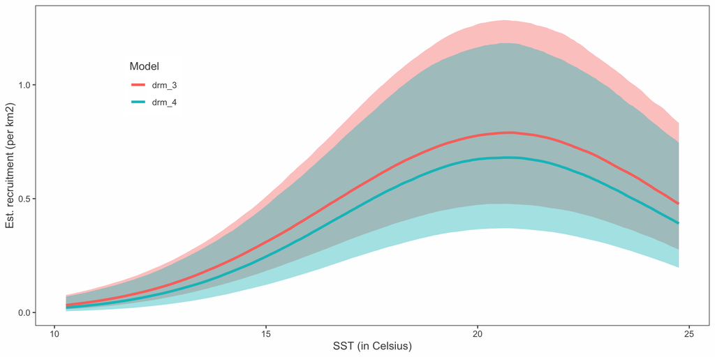

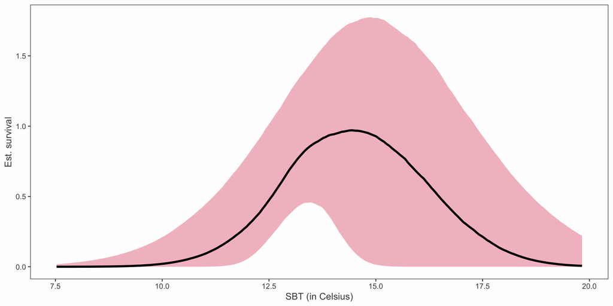

## Forecasting

- The code for obtaining out-of-sample predictions is quite intuitive.
- We only need to provide the output for a model fit, a new dataset (where we want the predictions), and a seed:

```r
forecast_3 <- predict_drm(drm = drm_3,
                          new_data = dat_test,
                          past_data = filter(dat_train,
                                             year == max(year)),
                          seed = 125,
                          cores = 4)
```

## Comparing models

| Model | $\Delta$-LOOIC | RMSE | IS | PIC | Time |
| --- | --- | --- | --- | --- | --- |
| `drm_3` | 0.00 | 8.98 | 8.60 | 78.0 | 13.34 |
| `sdm` | -6.07 | 12.04 | 12.72 | 60.0 | 3.88 |
| `drm_4` | -7.35 | 8.30 | 8.87 | 84.0 | 28.7 |
| `drm_5` | -7.74 | 8.23 | 8.96 | 86.0 | 19.24 |
| `drm_7` | -10.41 | 8.75 | 8.97 | 78.0 | 22.73 |
| `drm_6` | -18.04 | 10.22 | 10.49 | 86.0 | 33.73 |
| `drm_1` | -22.49 | 11.17 | 10.68 | 68.0 | 4.67 |
| `drm_2` | -32.32 | 10.73 | 10.29 | 68.0 | 4.44 |
| `baseline` | -163.85 | 14.44 | 12.98 | 74.0 | 1.35 |

# Concluding remarks

## Highlights

- The `drmr` substantially lowers the barrier for ecologists to use the DRM in their applications.
- The code is easy to use and takes advantage of what has been developed for `Stan`: visualization, diagnostic tools, and estimation.
- `drmr` allows for empirically testing which processes are more important to predict the distribution of a species.
- The more complex a model is, the more (and better) data we need to be able to estimate those relationships.

## Future work

- Application to NE Mackerel
- More options for spatial and temporal random effects for specific processes
- Other population dynamic models (e.g., Ricker, Belverton-Holt)
- GAM-like non-parametric relationships between processes and the environment
- Support for length-composition data
- More realistic movement routines

### References

Fredston, A., Ovando, D., Cunha Godoy, L. da, Kong, J., Muffley, B., Thorson, J. T., and Pinsky, M. (2025), “Dynamic range models improve the near-term forecast for a marine species on the move,” *Ecology Letters*, 00, (under review). https://doi.org/10.32942/X24D00.

Gabry, J., Češnovar, R., Johnson, A., and Bronder, S. (2024), *[cmdstanr: R interface to CmdStan](https://github.com/stan-dev/cmdstanr)*.

Guisan, A., and Thuiller, W. (2005), “Predicting species distribution: Offering more than simple habitat models,” *Ecology letters*, Wiley Online Library, 8, 993–1009. https://doi.org/https://doi.org/10.1111/j.1461-0248.2005.00792.x.

Pagel, J., and Schurr, F. M. (2012), “Forecasting species ranges by statistical estimation of ecological niches and spatial population dynamics,” *Global Ecology and Biogeography*, 21, 293–304. https://doi.org/https://doi.org/10.1111/j.1466-8238.2011.00663.x.